# #30DayChartChallenge

26 May 2022

## About me

- PhD Statistics and Operational Research
- Data scientist at Jumping Rivers
  - Consultancy: shiny, statistics, slides, …
  - Internal projects: blogdown websites, reports, plot styling, admin, …
  - Training: all things R (and some Tableau coming soon…)
- A lot of data visualisation…

## My R Journey

- Compulsory R coursework for a statistics course during undergraduate degree
- Learnt Python instead…
- Final year of undergrad gave R another go
- Started learning {tidyverse} during PhD

## Why data visualisation?

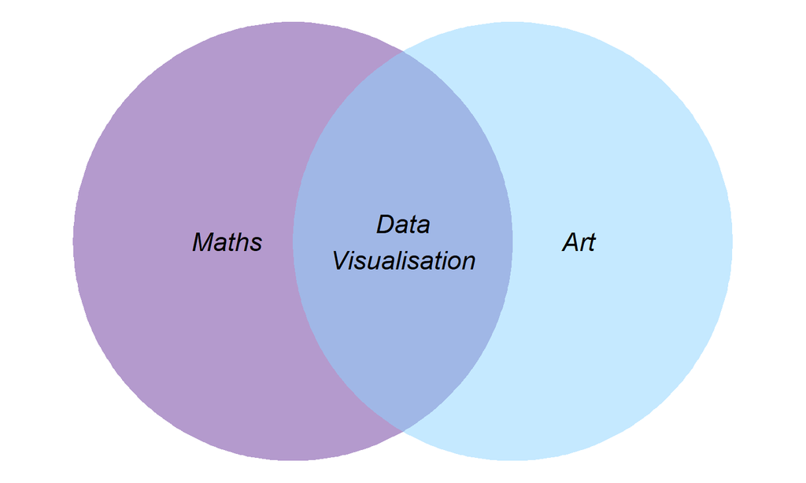

## #30DayChartChallenge

Part 1

## What is the #30DayChartChallenge?

- Data visualisation challenge where participants make one chart each day inspired by a daily prompt and category.
- Organised by [Cédric Scherer](https://twitter.com/CedScherer) and [Dominic Royé](https://twitter.com/dr_xeo), with support from [Wendy Shijia](https://twitter.com/ShijiaWendy) and [Marco Sciaini](https://twitter.com/shinysci).
- Post charts on Twitter with the #30DayChartChallenge (and #DayX)
- See also: [30daychartchallenge.org](https://30daychartchallenge.org/)

## Prompts

[figure not shown]

## Why did I make 30 charts?

- One “new tool” for each of the five categories
- Learn some new things
- Make charts that I wanted to make
- Have fun!

## How did I make 30 Charts?

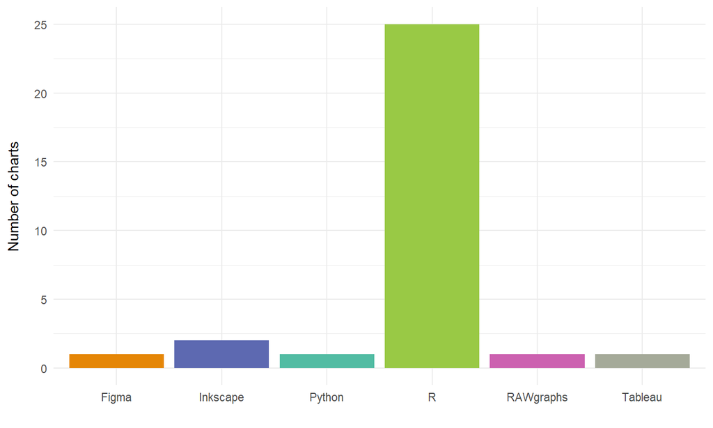

## The 30 Charts

[figure not shown]

## Day 1 (Part to whole) in R

[figure not shown]

## Day 2 (Pictogram) in R

[figure not shown]

## Day 3 (Historical) in R

[figure not shown]

## Day 4 (Flora) in Tableau (left) and R (right)

[figure not shown]

## Day 5 (Slope) in R

[figure not shown]

## Day 6 (Our World in Data) in R

[figure not shown]

## Day 7 (Physical) in R

[figure not shown]

## Day 8 (Mountains) in Figma

[figure not shown]

## Day 9 (Statistics) in R

[figure not shown]

## Day 10 (Experimental) in R

[figure not shown]

## Day 11 (Circular) in R

[figure not shown]

## Day 12 (The Economist) in R

[figure not shown]

## Day 13 (Correlation) in R

[figure not shown]

## Day 14 (3-Dimensional) in Python and R

[figure not shown]

## Day 15 (Multivariate) in R

[figure not shown]

## Day 16 (Environment) in R

[figure not shown]

## Day 17 (Connections) in R

[figure not shown]

## Day 18 (OECD) in R

[figure not shown]

## Day 19 (Global Change) in R

[figure not shown]

## Day 20 (New Tool) in Inkscape

[figure not shown]

## Day 21 (Down and Upwards) in R

[figure not shown]

## Day 22 (Animation) in R

[figure not shown]

## Day 23 (Tiles) in R

[figure not shown]

## Day 24 (Financial Times) in R

[figure not shown]

## Day 25 (Trend) in R

[figure not shown]

## Day 26 (Interactive) in R

[figure not shown]

## Day 27 (Future) in R

[figure not shown]

## Day 28 (Deviations) in RAWgraphs and Inkscape

[figure not shown]

## Day 29 (Storytelling) in R and Inkscape

[figure not shown]

## Day 30 (UN Population) in R

[figure not shown]

## Lessons Learned

## What did I learn?

- R packages
  - `facet_zoom()` from {ggforce}
  - Quarto
  - {tidytext}
- Non-R tools can be very helpful…
- Repeating styles should be bundled into an R package

## What did I find difficult?

- Time
  - Didn’t make charts each day, took breaks, reuse data
- Fitting my ideas and things I wanted to try to fit prompts
  - More planning

## The Goldilocks Decision Tree

Part 2

[figure not shown]

## Flow charts in R

- {grid}
- {DiagrammeR}
- {igraph}
- {ggnetwork} / {ggnet2} / {ggraph}
- {tikz} (LaTeX)
- others…

Let’s try to make a flowchart with {ggplot2}…

## R Packages

```r
library(tidyverse)
library(igraph)
library(showtext)
library(rcartocolor)
```

## Data

```r
goldilocks <- tibble(from = c("Goldilocks",
                              "Porridge", "Porridge", "Porridge",
                              "Just right",
                              "Chairs", "Chairs", "Chairs",
                              "Just right2",
                              "Beds", "Beds", "Beds",
                              "Just right3"),
                     to = c("Porridge",
                            "Too cold", "Too hot", "Just right",
                            "Chairs",
                            "Still too big", "Too big", "Just right2",
                            "Beds",
                            "Too soft", "Too hard", "Just right3",
                            "Bears!"))
```

```
## # A tibble: 6 × 2
##   from       to
##   <chr>      <chr>
## 1 Goldilocks Porridge
## 2 Porridge   Too cold
## 3 Porridge   Too hot
## 4 Porridge   Just right
## 5 Just right Chairs
## 6 Chairs     Still too big
```

## Defining the layout

```r
g = graph_from_data_frame(goldilocks, directed = TRUE)
coords = layout_as_tree(g)
colnames(coords) = c("x", "y")
```

```
##       x y
## [1,]  0 7
## [2,]  0 6
## [3,] -1 5
## [4,] -1 4
## [5,] -2 3
## [6,] -2 2
```

## Adding attributes

```r
output_df = as_tibble(coords) %>%
  mutate(step = vertex_attr(g, "name"),
         x = x*-1,
         type = factor(c(1, 2, 3, 2, 3, 2, 3, 3, 3, 3, 3, 3, 3, 1)),
         label = gsub("\\d+$", "", step))
```

```
## # A tibble: 6 × 5
##       x     y step        type  label
##   <dbl> <dbl> <chr>       <fct> <chr>
## 1     0     7 Goldilocks  1     Goldilocks
## 2     0     6 Porridge    2     Porridge
## 3     1     5 Just right  3     Just right
## 4     1     4 Chairs      2     Chairs
## 5     2     3 Just right2 3     Just right
## 6     2     2 Beds        2     Beds
```

## Making the boxes

```r
plot_nodes = output_df %>%
  mutate(xmin = x - 0.35,
         xmax = x + 0.35,
         ymin = y - 0.25,
         ymax = y + 0.25)
```

```
## # A tibble: 6 × 9
##       x     y step        type  label       xmin  xmax  ymin  ymax
##   <dbl> <dbl> <chr>       <fct> <chr>      <dbl> <dbl> <dbl> <dbl>
## 1     0     7 Goldilocks  1     Goldilocks -0.35  0.35  6.75  7.25
## 2     0     6 Porridge    2     Porridge   -0.35  0.35  5.75  6.25
## 3     1     5 Just right  3     Just right  0.65  1.35  4.75  5.25
## 4     1     4 Chairs      2     Chairs      0.65  1.35  3.75  4.25
## 5     2     3 Just right2 3     Just right  1.65  2.35  2.75  3.25
## 6     2     2 Beds        2     Beds        1.65  2.35  1.75  2.25
```

## Making the edges

```r
plot_edges = goldilocks %>%
  mutate(id = row_number()) %>%
  pivot_longer(cols = c("from", "to"),
               names_to = "s_e",
               values_to = "step") %>%
  left_join(plot_nodes, by = "step") %>%
  select(-c(label, type, y, xmin, xmax)) %>%
  mutate(y = ifelse(s_e == "from", ymin, ymax)) %>%
  select(-c(ymin, ymax))
```

```
## # A tibble: 3 × 5
##      id s_e   step           x     y
##   <int> <chr> <chr>      <dbl> <dbl>
## 1     1 from  Goldilocks     0  6.75
## 2     1 to    Porridge       0  6.25
## 3     2 from  Porridge       0  5.75
```

## Choosing fonts

- Google fonts and the {showtext} package
- Browse fonts: [fonts.google.com](https://fonts.google.com/)

```r
library(showtext)
font_add_google(name = "Henny Penny", family = "henny")
showtext_auto()
```

## Plotting (finally!)

```r
p = ggplot() +
  # draw rectangles
  geom_rect(data = plot_nodes,
            mapping = aes(xmin = xmin, ymin = ymin, xmax = xmax, ymax = ymax,
                          fill = type, colour = type),
            alpha = 0.5,
            linejoin = "round") +
  # add text labels
  geom_text(data = plot_nodes,
            mapping = aes(x = x, y = y, label = label),
            family = "henny",
            color = "#585c45") +
  # add arrows
  geom_path(data = plot_edges,
            mapping = aes(x = x, y = y, group = id),
            colour = "#585c45",
            arrow = arrow(length = unit(0.3, "cm"), type = "closed"))
```

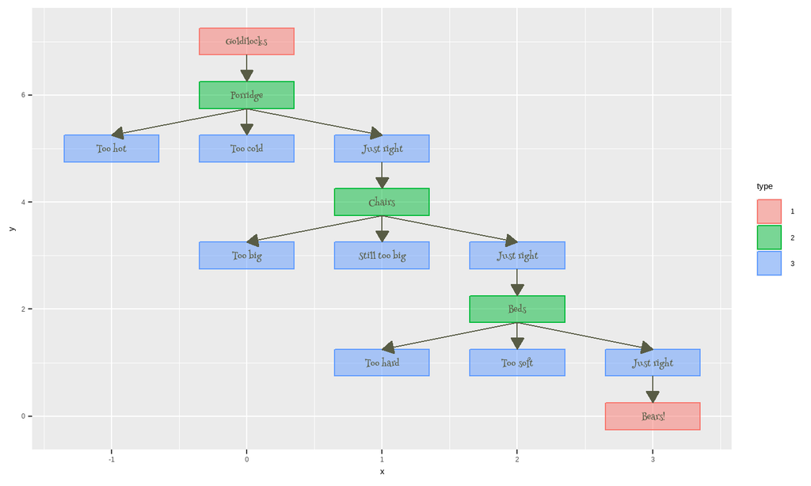

```r
p
```

## Colour schemes

- {rcartocolor}: [jakubnowosad.com/rcartocolor](https://jakubnowosad.com/rcartocolor/)

```r
p = p +
  scale_fill_carto_d(palette = "Antique") +
  scale_colour_carto_d(palette = "Antique")
```

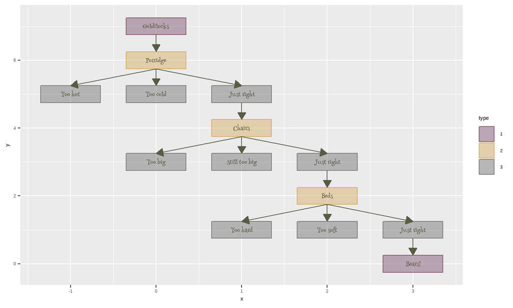

```r
p
```

## Some text labels

```r
p = p +
  labs(title = "The Goldilocks Decision Tree",
       caption = "N. Rennie\n\nData: Robert Southey. Goldilocks and the Three Bears.
       1837.\n\nImage: New York Public Library\n\n#30DayChartChallenge")
```

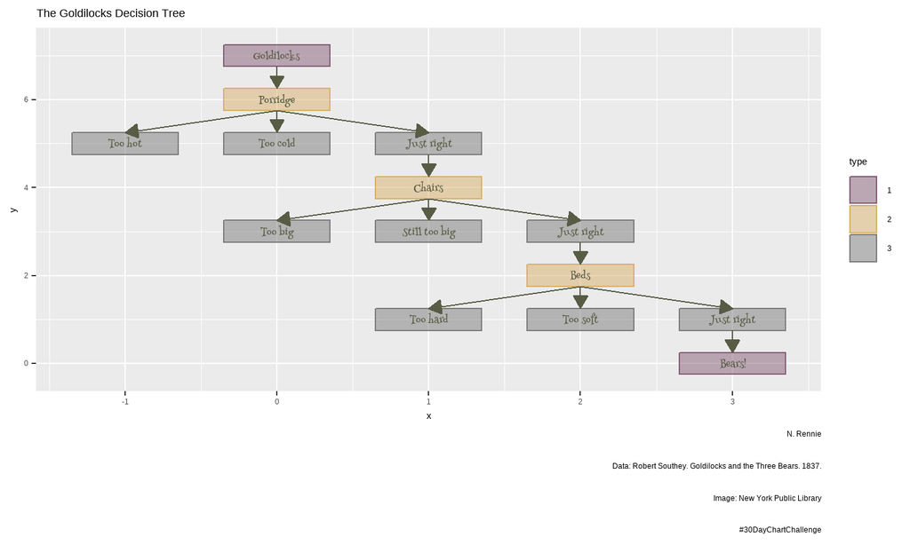

```r
p
```

## Background colours

- Choose image
- Extract hex colour: [imagecolorpicker.com](https://imagecolorpicker.com/en)

[figure not shown]

## Themes

```r
p = p +
  theme_void() +
  theme(plot.margin = unit(c(1, 1, 0.5, 1), "cm"),
        legend.position = "none",
        plot.background = element_rect(colour = "#f2e4c1", fill = "#f2e4c1"),
        panel.background = element_rect(colour = "#f2e4c1", fill = "#f2e4c1"),
        plot.title = element_text(family = "henny", hjust = 0, face = "bold",
                                  size = 40, color = "#585c45",
                                  margin = margin(t = 10, r = 0, b = 10, l = 0)),
        plot.caption = element_text(family = "henny", hjust = 0,
                                    size = 10, color = "#585c45",
                                    margin = margin(t = 10)))
```

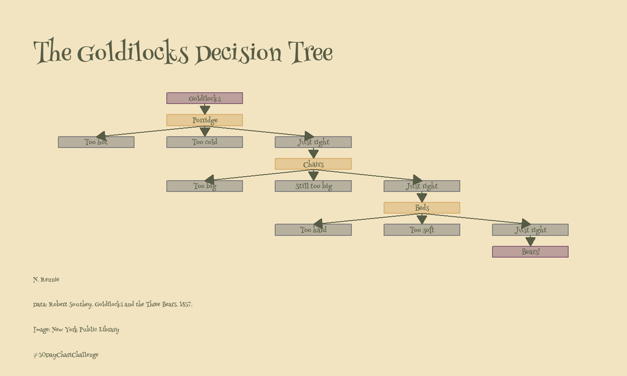

```r
p
```

## Adding images

- {magick} and {cowplot}
- Inkscape: [inkscape.org](https://inkscape.org/release/inkscape-1.2/)

[figure not shown]

## Questions?

- Twitter: [@nrennie35](https://twitter.com/nrennie35)
- GitHub: github.com/nrennie
- Website: [nrennie.rbind.io](https://nrennie.rbind.io/)
- Slides: nrennie.rbind.io/talks/2022-may-rladies-nairobi/